# Лабораторная работа №15

Модели обслуживания с приоритетами

Шубнякова Дарья НКНбд-01-22

1132226452@pfur.ru

Российский университет дружбы народов

# Вводная часть

## Цели и задачи

Ознакомится с двумя моделями обслуживания с приоритетами:

1. Модель обслуживания механиков на складе
2. Модель обслуживания в порту судов двух типов

Получить и проанализировать два отчета по обеим задачам.

# Основная часть

## Выполнение лабораторной работы

На фабрике на складе работает один кладовщик, который выдает запасные части механикам, обслуживающим станки. Время, необходимое для удовлетворения за- проса, зависит от типа запасной части. Запросы бывают двух категорий. Для первой категории интервалы времени прихода механиков 420 ± 360 сек., время обслужива- ния — 300 ± 90 сек. Для второй категории интервалы времени прихода механиков 360 ± 240 сек., время обслуживания — 100 ± 30 сек. Порядок обслуживания механиков кладовщиком такой: запросы первой категории обслуживаются только в том случае, когда в очереди нет ни одного запроса второй категории. Внутри одной категории дисциплина обслуживания — «первым пришел – первым обслужился». Необходимо создать модель работы кладовой, моделирование выполнять в течение восьмичасового рабочего дня.

## Вводим код для первой задачи, предоставленный в лабораторной работе, знакомимся с отчетом.

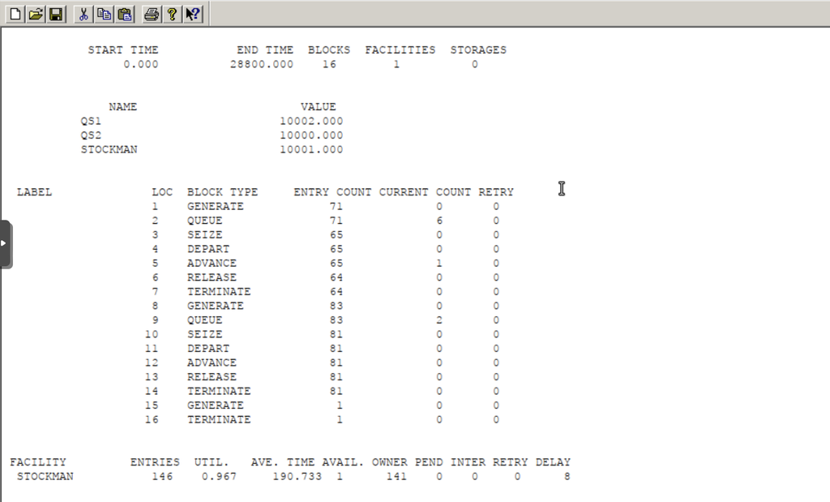

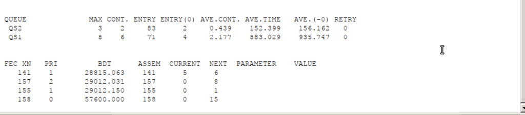

## Морские суда двух типов прибывают в порт, где происходит их разгрузка. В порту есть два буксира, обеспечивающих ввод и вывод кораблей из порта. К первому типу судов относятся корабли малого тоннажа, которые требуют использования одного буксира. Корабли второго типа имеют большие размеры, и для их ввода и вывода из порта требуется два буксира. Из-за различия размеров двух типов кораблей необходимы и причалы различного размера. Кроме того, корабли имеют различное время погрузки/разгрузки. Получаем отчет и анализируем его.

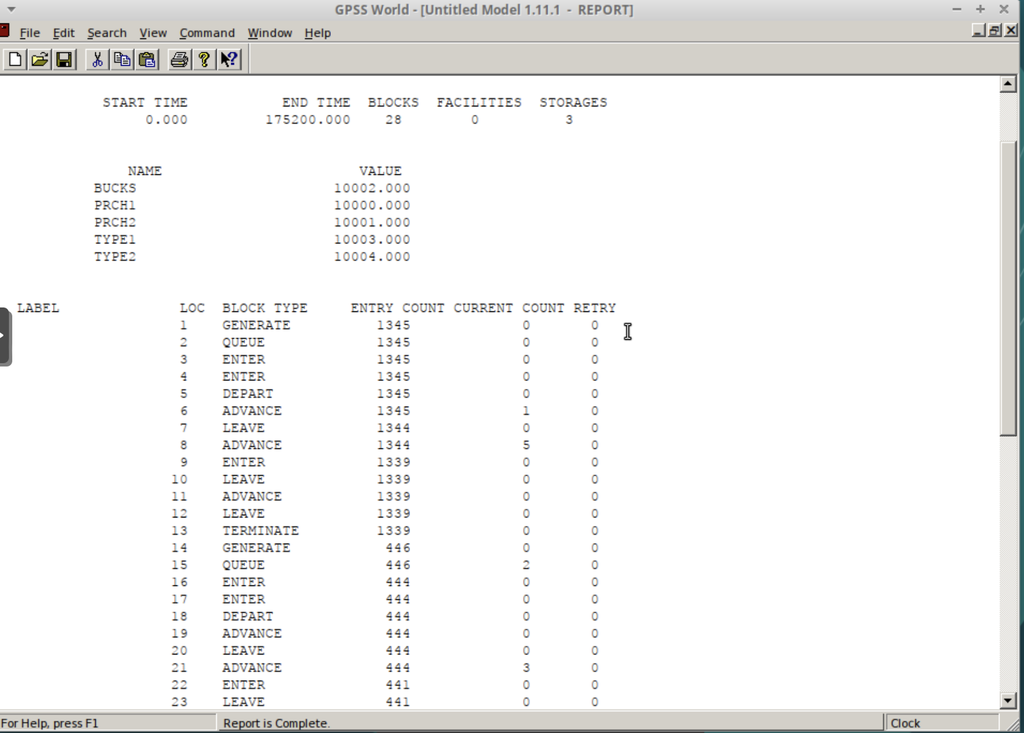

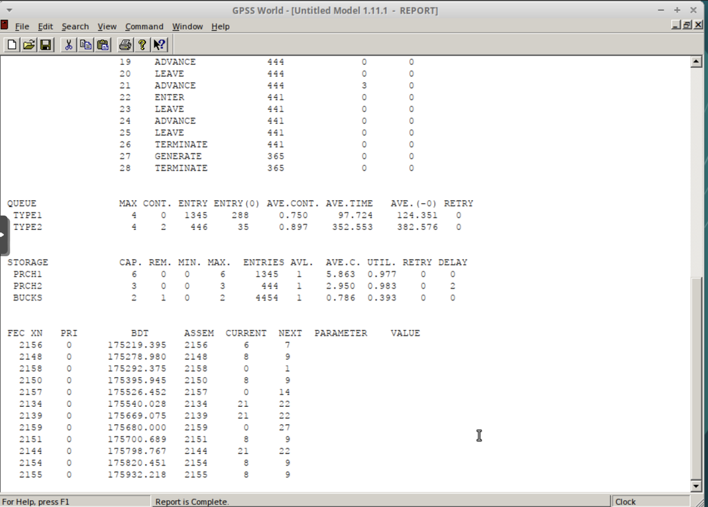

# Результаты

Мы ознакомились с работой с моделями обслуживания с приоритетами в GPSS. Реализовали две задачи:

1. Модель обслуживания механиков на складе
2. Модель обслуживания в порту судов двух типов